# Beobachtungsstudie: Gruppenvergleiche und Regressionsanalysen

OLS-, Poisson- und Negativ-Binomial-Regression

Autor:in

Stefan Kruse

**Datenhinweis:** Alle Versicherten, Krankenhausaufnahmen, Kosten und Programmteilnahmen in diesem Lehrprojekt sind **vollständig synthetisch**.

# 1 Forschungsfrage und Studiendesign

**Forschungsfrage:** Unterscheiden sich die HF-bedingten Krankenhausaufnahmen von Personen mit und ohne Telemonitoring im Jahr 2025? Wie verändert sich unser Ergebnis, wenn wir bereits vor Programmstart bestehende Unterschiede zwischen den Gruppen berücksichtigen?

Im Unterschied zu einem randomisierten Experiment erfolgte die Teilnahme hier **nicht zufällig**. Beispielsweise können Personen mit schwererer Herzinsuffizienz häufiger für das Programm ausgewählt werden und zugleich ein höheres Hospitalisierungsrisiko aufweisen. Ein einfacher Vergleich der Gruppen kann deshalb durch *Confounding by Indication* verzerrt sein.

**Primäres Outcome:** Anzahl ungeplanter, herzinsuffizienzbezogener stationärer Aufnahmen je 365 Tage unter Beobachtung. **Sekundäre Outcomes:** Kosten der Krankenversicherung und Zeit bis zur ersten HF-Hospitalisierung.

Der Wirkmechanismus ist vereinfacht: Telemonitoring → frühzeitiges Erkennen einer Verschlechterung → ambulante Reaktion → weniger ungeplante Krankenhauseinweisungen. Das Programm verursacht zugleich zusätzliche Gebühren. Wir analysieren erst die Wirkung und anschließend getrennt die mögliche langfristige Wirtschaftlichkeit.

**Abkürzungen:** HF = Herzinsuffizienz; GKV = gesetzliche Krankenversicherung; NYHA = Funktionsklassifikation der New York Heart Association; LVEF = linksventrikuläre Ejektionsfraktion;

| Zeitpunkt | Kalenderzeit | Rolle |
| --- | --- | --- |
| T−2 | 2023 | Erste Vorperiode und erste Trendmessung |
| T−1 | 2024 | Zweite Vorperiode, letzte Daten vor Entscheidung |
| T0 | 01.01.2025 | Programmstart / definierter Index für beide Gruppen |
| T+1 | 2025 | 365 Tage Nachbeobachtung; Tod führt zu kürzerer Risikozeit |

Die Teilnahme erfolgt **nicht zufällig**: höhere Krankheitslast, mehr vorherige HF-Aufnahmen und digitaler Zugang wirken auf die Einschreibung. Eine rein fiktive Einladungsschwelle bei einem Risiko-Score von **70 Punkten** erhöht die Teilnahme zusätzlich sprunghaft. Dieser Score ist **kein reales G-BA-Zugangskriterium**. Diese Schwelle ermöglicht später einen *fuzzy* RD-Ansatz.

In diesem Kapitel vergleichen wir absolute Unterschiede in annualisierten Hospitalisierungszahlen (lineare Regression) mit relativen Hospitalisierungsraten (Poisson-Regression). Die Modelle beschreiben zunächst **adjustierte Zusammenhänge**. Eine kausale Interpretation würde zusätzlich korrekte Modellannahmen erfordern.

**Auftraggeber:** Fiktive gesetzliche Krankenkasse. **Intervention:** Telemedizinisches Monitoring und koordinierte Betreuung von Patientinnen und Patienten mit Herzinsuffizienz (Beginn 1. Januar 2025). **Kontrolle:** Versorgung ohne Programmteilnahme. **Population:** 2.000 fiktive Versicherte mit dokumentierter Herzinsuffizienz; 2023 und 2024 sind Vorperioden, 2025 die einjährige Nachperiode.

## 1.1 Analyse-Logik und Zielgrößen

| Methode | Was wird geschätzt? | Zentraler Identifikationsgedanke |
| --- | --- | --- |
| Unadjustiert | Beobachtete Gruppendifferenz | Keine kausale Identifikation |
| Regression | Kovariatenadjustierte Gruppendifferenz | Kein unbeobachtetes Confounding |

# 2 Pakete und Daten einlesen

## 2.1 Benötigte R-Pakete

Installiere die folgenden Pakete bei Bedarf einmalig über die R-Konsole:

```r
# install.packages(c("fixest", "dplyr", "vtable", "explore", "ggplot2", "knitr", "labelled"))
```

Die Pakete werden hier ausdrücklich geladen, sodass die verwendeten Funktionen im Skript erkennbar bleiben.

```r
library(fixest)    # Regressionsmodelle und robuste Standardfehler
library(ggplot2)   # Grafiken
library(knitr)     # Tabellen
library(explore)
library(vtable)
library(dplyr)
library(labelled)
```

## 2.2 Importieren der CSV-Dateien

Wir verwenden 4 der bereitgestellten CSV-Dateien:

- `01_versicherte_baseline.csv`: eine Zeile je Person; Ausgangsmerkmale, Hospitalisierungen vor 2025 und Programmteilnahme.
- `02_versichertenjahre_panel.csv`: eine Zeile je Person und Jahr; Beobachtungszeit und Kosten für 2023–2025.
- `03_ereigniszeit_2025.csv`: eine Zeile je Person; Hospitalisierungen in 2025.
- `datenwoerterbuch.csv`

Beim Rendern führt Quarto die R-Befehle standardmäßig relativ zum Verzeichnis dieser `.qmd`-Datei aus. Deshalb führt `../../data/` zum Datenordner im Repository-Hauptverzeichnis.

```r
# Verzeichnis mit den synthetischen CSV-Dateien
ordner_daten <- "../../data"

# Vollständige Dateipfade erstellen
datei_baseline <- file.path(ordner_daten, "01_versicherte_baseline.csv")
datei_panel <- file.path(ordner_daten, "02_versichertenjahre_panel.csv")
datei_ereigniszeit_2025 <- file.path(ordner_daten, "03_ereigniszeit_2025.csv")

# Vor dem Einlesen prüfen, ob beide Dateien existieren
if (!file.exists(datei_baseline) || !file.exists(datei_panel)) {
  stop("CSV-Dateien nicht gefunden. Bitte Ordnerstruktur und Dateipfade prüfen.")
}

# Eine Zeile je versicherter Person
stamm <- read.csv(datei_baseline, stringsAsFactors = FALSE)

# Eine Zeile je Person und Beobachtungsjahr
panel <- read.csv(datei_panel, stringsAsFactors = FALSE)

# Eine Zeile je versicherter Person
ereigniszeit <- read.csv(datei_ereigniszeit_2025, stringsAsFactors = FALSE)

# Überblick über die importierten Daten
cat("Personen im Baseline-Datensatz:", nrow(stamm), "\n")
```

```
Personen im Baseline-Datensatz: 2000
```

```r
cat("Personenjahre im Panel-Datensatz:", nrow(panel), "\n")
```

```
Personenjahre im Panel-Datensatz: 6000
```

```r
table(panel$jahr)
```

```
2023 2024 2025
2000 2000 2000
```

## 2.3 Merge Stammdaten mit outcomes

Für die Regressionsanalysen benötigen wir **eine Zeile je Person**. Dazu nehmen wir die Ausgangsmerkmale aus `stamm` und ergänzen die Outcomes und Beobachtungszeiten für das Jahr 2025 aus `panel`.

```r
# 1. Prüfen, ob Personen eindeutig identifiziert werden können
if (any(duplicated(stamm$person_id))) {
  stop("Die Baseline-Datei enthält doppelte Personen-IDs.")
}

if (any(duplicated(panel[c("person_id", "jahr")]))) {
  stop("Im Panel gibt es doppelte Kombinationen aus Person und Jahr.")
}

# 2. Nur das Programmjahr 2025 auswählen
panel_2025 <- panel[panel$jahr == 2025, ]

# 3. Benötigte Variablen aus den beiden Datensätzen definieren
nach <- panel_2025[, c(
  "person_id",
  "hf_hosp_rate_365",
  "gkv_gesamtkosten_eur",
  "beobachtungstage"
)]

nach2 <- ereigniszeit[, c("person_id", "hf_hosp_2025")]


# 4. Klarstellen, dass die Variablen aus dem Paneldatensatz das Jahr 2025 betreffen
names(nach) <- c(
  "person_id",
  "hf_hosp_rate_post_annual",
  "gkv_gesamtkosten_post",
  "beobachtungstage_post"
)


# 5. Daten anhand der Personen-ID miteinander verbinden
#    all.x = TRUE: alle Personen aus dem Baseline-Datensatz behalten
analyse <- merge(stamm, nach, by = "person_id", all.x = TRUE)

analyse <- merge(analyse, nach2, by = "person_id", all.x = TRUE)

# Ändern der Reihenfolge
analyse <- analyse |>
  relocate(hf_hosp_2025, hf_hosp_rate_post_annual, .after = hf_hosp_2024)

# 6. Sicherstellen, dass jede Person genau einmal vorkommt
if (nrow(analyse) != nrow(stamm)) {
  stop("Nach dem Zusammenführen stimmt die Anzahl der Personen nicht.")
}

if (any(is.na(analyse))) {
  stop("Im Analysedatensatz fehlen Werte. Bitte den Datenimport prüfen.")
}

if (any(analyse$beobachtungstage_post <= 0)) {
  stop("Alle Personen benötigen eine positive Beobachtungszeit.")
}

if (!all(analyse$teilnahme %in% c(0, 1))) {
  stop("Die Programmteilnahme muss mit 0 oder 1 kodiert sein.")
}

# 7. Lesbare Gruppennamen für Tabellen und Grafiken erstellen
# Aus der num. Variable teilnahme eine neue Faktorvariable erstellen
analyse$gruppe <- factor(
  analyse$teilnahme,
  levels = c(0, 1),
  labels = c("Kontrolle", "Telemonitoring")
)

# 8. Sortierung der Variablen ändern
analyse <- analyse |>
  relocate(gruppe, .after = teilnahme)


analyse <- analyse |>
  relocate(person_id, hf_hosp_2023, hf_hosp_2024, hf_hosp_2025, hf_hosp_rate_post_annual, beobachtungstage_post, teilnahme, gruppe)
```

**Warum `merge()`?** Die Baseline- und die Paneldatei enthalten jeweils die Variable `person_id`. Über diese gemeinsame ID lassen sich die Angaben zu derselben Person zusammenführen. Mit `all.x = TRUE` behalten wir alle Baseline-Personen; die anschließenden Prüfungen zeigen, ob für jemanden Angaben aus dem Jahr 2025 fehlen.

## 2.4 Variablenlabels und Codebook erstellen

```r
# Datenwörterbuch importieren
woerterbuch <- read.csv(
  file.path(ordner_daten, "datenwoerterbuch.csv"),
  fileEncoding = "UTF-8"
)

# Doppelte Einträge entfernen
woerterbuch <- woerterbuch[!duplicated(woerterbuch$variable), ]

# Variablennamen und deutsche Bezeichnungen verknüpfen
labels <- setNames(woerterbuch$deutsche_bezeichnung,
  woerterbuch$variable)

# Umbenannte Variablen aus dem Panel berücksichtigen
post_variablen <- c(
  hf_hosp_rate_post_annual = "hf_hosp_rate_365",
  gkv_gesamtkosten_post = "gkv_gesamtkosten_eur",
  beobachtungstage_post = "beobachtungstage",
  programmkosten_post = "programmkosten_eur"
)

# Labels für die umbenannten Variablen erzeugen
post_labels <- labels[post_variablen]
post_labels <- paste0(post_labels, " (Nachperiode 2025)")
names(post_labels) <- names(post_variablen)

# Alle verfügbaren Labels zusammenführen
labels <- c(labels, post_labels)

# Nur vorhandene Variablen mit gültigen Labels berücksichtigen
labels <- labels[names(labels) %in% names(analyse)]
labels <- labels[!is.na(labels) & nzchar(labels)]

# Labels direkt dem gesamten Dataframe zuweisen
analyse <- labelled::set_variable_labels(
  analyse,
  .labels = as.list(labels)
)

# Alle Variablen und ihre Labels anzeigen
labelled::look_for(analyse) |>
  dplyr::select(variable, label, col_type, missing) |>
  knitr::kable(
    col.names = c("Variable", "Variablenlabel", "Datentyp", "Fehlwerte")
  )
```

| Variable | Variablenlabel | Datentyp | Fehlwerte |
| --- | --- | --- | --- |
| person_id | Pseudonymisierte Person | chr | 0 |
| hf_hosp_2023 | HF-Hospitalisierungen 2023 | int | 0 |
| hf_hosp_2024 | HF-Hospitalisierungen 2024 | int | 0 |
| hf_hosp_2025 | HF-Aufnahmen 2025 | int | 0 |
| hf_hosp_rate_post_annual | Auf 365 Risiko-Tage annualisierte HF-Aufnahmerate (Nachperiode 2025) | dbl | 0 |
| beobachtungstage_post | Tage unter Risiko (Nachperiode 2025) | int | 0 |
| teilnahme | Teilnahme am Programm ab 01.01.2025 | int | 0 |
| gruppe | NA | fct | 0 |
| alter_2025 | Alter am Indexdatum | int | 0 |
| geschlecht | Geschlecht | chr | 0 |
| region | Fiktive Versorgungsregion | chr | 0 |
| laendlich | Wohnort ländlich | int | 0 |
| nyha | Symptomschwere nach NYHA | int | 0 |
| lvef_prozent | Linksventrikuläre Ejektionsfraktion | dbl | 0 |
| diabetes | Diabetesdiagnose | int | 0 |
| niereninsuffizienz | Chronische Nierenerkrankung | int | 0 |
| copd | Chronisch obstruktive Lungenerkrankung | int | 0 |
| hypertonie | Bluthochdruck | int | 0 |
| digitalzugang | Digitaler Zugang für Telemedizin | int | 0 |
| gkv_kosten_2023_eur | Simulierte Gesamtkosten 2023 | dbl | 0 |
| gkv_kosten_2024_eur | Simulierte Gesamtkosten 2024 | dbl | 0 |
| risiko_score | Simulierter Einladungs-Score | dbl | 0 |
| einladung_ab_70 | Gezielte Einladung nach Score ≥ 70 | int | 0 |
| gkv_gesamtkosten_post | Simulierte GKV-Jahreskosten (Nachperiode 2025) | dbl | 0 |

# 3 Deskriptive Analyse und Gruppenvergleich

```r
options(scipen=100)
options(digits=2)

analyse |>
  select(nyha, hf_hosp_2023, hf_hosp_2024, hf_hosp_2025, hf_hosp_rate_post_annual, diabetes, hypertonie, copd, niereninsuffizienz) |>
  explore:: describe()
```

```
# A tibble: 9 × 8
  variable                 type     na na_pct unique   min  mean   max
  <chr>                    <chr> <int>  <dbl>  <int> <dbl> <dbl> <dbl>
1 nyha                     int       0      0      3     2  2.55     4
2 hf_hosp_2023             int       0      0      8     0  0.67     7
3 hf_hosp_2024             int       0      0      7     0  0.83     6
4 hf_hosp_2025             int       0      0      7     0  0.8      6
5 hf_hosp_rate_post_annual dbl       0      0     47     0  0.86    73
6 diabetes                 int       0      0      2     0  0.46     1
7 hypertonie               int       0      0      2     0  0.66     1
8 copd                     int       0      0      2     0  0.18     1
9 niereninsuffizienz       int       0      0      2     0  0.29     1
```

```r
analyse |>
  select(nyha, hf_hosp_2023, hf_hosp_2024, hf_hosp_2025, hf_hosp_rate_post_annual, diabetes, hypertonie, copd, niereninsuffizienz) |>
  sumtable(out='return', digits = 3)
```

```
                  Variable    N  Mean Std. Dev. Min Pctl. 25 Pctl. 75 Max
1                     nyha 2000  2.55     0.611   2        2        3   4
2             hf_hosp_2023 2000 0.671     0.925   0        0        1   7
3             hf_hosp_2024 2000  0.83     0.958   0        0        1   6
4             hf_hosp_2025 2000   0.8     0.909   0        0        1   6
5 hf_hosp_rate_post_annual 2000 0.858      1.88   0        0        1  73
6                 diabetes 2000  0.46     0.498   0        0        1   1
7               hypertonie 2000 0.664     0.472   0        0        1   1
8                     copd 2000 0.176     0.381   0        0        0   1
9       niereninsuffizienz 2000 0.289     0.453   0        0        1   1
```

Neben der Anzahl der Hospitalisierungen pro Jahr pro Person berechnen wir die annualisierte Hospitalisierungsrate. Die Annualisierung ermöglicht den Vergleich unterschiedlicher Beobachtungszeiten, kann aber bei kurzen Zeiträumen sehr große Werte erzeugen.

Bsp: Eine Person hatte zwei Krankenhausaufnahmen innerhalb von 180 Beobachtungstagen (und verstarb dann oder wurde nicht weiter beobachtet). Ihre annualisierte Hospitalisierungsrate beträgt = (2/180) * 365 = 4,06 Das bedeutet nicht, dass die Person tatsächlich 4,06 Krankenhausaufnahmen hatte. Beobachtet wurden lediglich zwei Aufnahmen. Die Zahl 4,06 beschreibt die auf ein Jahr hochgerechnete Ereignishäufigkeit.

**Wichtig:** Der Durchschnitt einzelner annualisierter Personenraten ist nicht notwendigerweise identisch mit der gepoolten Ereignisrate (alle Ereignisse geteilt durch die gesamte Beobachtungszeit).

```r
library(dplyr)

vergleich <- analyse |>
  group_by(gruppe) |>
  summarise(
    N = n(),
    Alter = mean(alter_2025),
    nyha_median = median(nyha),
    diabetes_pc = 100*mean(diabetes),
    hypertonie_pc = 100*mean(hypertonie),
    copd_pc = 100*mean(copd),
    niereninsuffizienz_pc = 100*mean(niereninsuffizienz),
    hf_hosp_2023 = mean(hf_hosp_2023),
    hf_hosp_2024 = mean(hf_hosp_2024),
    hf_hosp_2025 = mean(hf_hosp_2025),
    hf_hosp_rate_post_annual = mean(hf_hosp_rate_post_annual),
    .groups = "drop"
  )

knitr::kable(vergleich, digits = 2,
  caption = "Mittelwerte nach Studiengruppe")
```

Mittelwerte nach Studiengruppe

| gruppe | N | Alter | nyha_median | diabetes_pc | hypertonie_pc | copd_pc | niereninsuffizienz_pc | hf_hosp_2023 | hf_hosp_2024 | hf_hosp_2025 | hf_hosp_rate_post_annual |
| --- | --- | --- | --- | --- | --- | --- | --- | --- | --- | --- | --- |
| Kontrolle | 1148 | 70 | 2 | 41 | 64 | 17 | 21 | 0.5 | 0.64 | 0.8 | 0.82 |
| Telemonitoring | 852 | 73 | 3 | 53 | 69 | 18 | 39 | 0.9 | 1.08 | 0.8 | 0.91 |

**Verständnisfrage**: Warum ist eine höhere Hospitalisierungsrate bei Teilnehmenden kein Beleg für Programmversagen? Vergleiche dafür NYHA (Herzinsuffizienz-Schweregrad) und hf_hosp_2024 (frühere stationäre Aufnahmen).

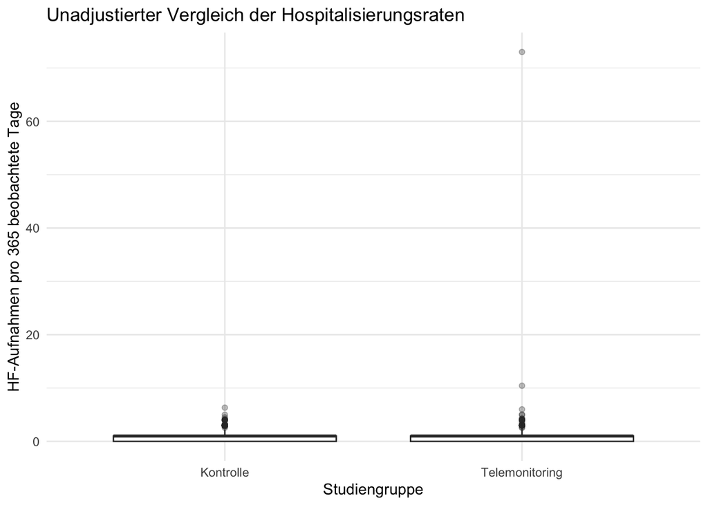

```r
ggplot(analyse, aes(x = gruppe, y = hf_hosp_rate_post_annual)) +
  geom_boxplot(outlier.alpha = 0.3) +
  labs(x = "Studiengruppe", y = "HF-Aufnahmen pro 365 beobachtete Tage",
    title = "Unadjustierter Vergleich der Hospitalisierungsraten") + theme_minimal()
```

**Interpretation**: Das Boxplot zeigt, dass es in der Interventionsgruppe einzelne Ausreißer gibt! Dies liegt u.a. in der Berechnung der annualisierten Hospitalisierungsgruppe begründet.

# 4 OLS Regression

Wir beginnen mit einer unadjustierten linearen Regression. Für die Regressionsadjustierung verwenden wir ausschließlich Informationen, die bereits vor dem Programmstart vorlagen. Insbesondere kontrollieren wir nicht für spätere Krankenhausaufnahmen oder Programmkosten.

Der `risiko_score` fasst prognostische Informationen zusammen und kann mit einzelnen Kovariaten korreliert sein. Er wird hier wegen möglicher Kollinearität ausgeschlossen. Die Einladungsschwelle `einladung_ab_70` lag ebenfalls vor dem Programmstart; und ist für den Teilnahmeprozess relevant. Für die Regressionsadjustierung verwenden wir somit nur ausgewählte klinische, demografische und versorgungsbezogene Ausgangsmerkmale. Den zusammengesetzten risiko_score und die daraus abgeleitete Einladungsschwelle einladung_ab_70 nehmen wir bewusst nicht zusätzlich auf. Die Regression dient damit als Modell zur Adjustierung anhand der ausgewählten Einzelmerkmale. Der Einfluss der Einladungsschwelle wird im späteren Regression-Discontinuity-Modul gesondert untersucht.

```r
modell_roh <- feols(hf_hosp_rate_post_annual ~ teilnahme, data = analyse, vcov = "hetero")

etable(modell_roh, digits = 3)
```

```
                              modell_roh
Dependent Var.: hf_hosp_rate_post_annual

Constant                0.818*** (0.028)
teilnahme                  0.094 (0.096)
_______________ ________________________
S.E. type       Heteroskedasticity-robu.
Observations                       2,000
R2                               0.00061
Adj. R2                          0.00011
---
Signif. codes: 0 '***' 0.001 '**' 0.01 '*' 0.05 '.' 0.1 ' ' 1
```

Der Koeffizient `teilnahme` entspricht hier der **absoluten Differenz** der mittleren annualisierten Hospitalisierungszahlen zwischen den Teilnehmenden und der Kontrollgruppe. Heteroskedastizitätsrobuste Standardfehler berücksichtigen bestimmte Unterschiede in der Fehlervarianz; sie beseitigen aber **kein Confounding**.

Ein positiver Koeffizient bedeutet, dass Programmteilnehmende häufiger hospitalisiert werden. Das heißt jedoch nicht zwangsläufig, dass das Programm unwirksam oder schädlich ist: Personen mit schwererer Erkrankung und höherem Hospitalisierungsrisiko nehmen häufiger am Programm teil. Diese systematischen Unterschiede zwischen den Gruppen können das Ergebnis verzerren (Confounding by Indication).

Zwischenfazit: Der unadjustierte Vergleich zeigt zunächst nur einen Zusammenhang (bzw. in diesem Fall keinen signifikanten Zusammenhang), keinen kausalen Programmeffekt. Um die tatsächliche Wirkung des Telemonitorings abzuschätzen, müssen wir die Unterschiede zwischen den Gruppen berücksichtigen.

```r
# Umfangreichere Adjustierung:
modell_adjustiert <- feols(hf_hosp_rate_post_annual ~ teilnahme
                    + alter_2025 + geschlecht +
                    nyha + lvef_prozent + diabetes + niereninsuffizienz + copd +
                  hypertonie + digitalzugang + laendlich + hf_hosp_2023 + hf_hosp_2024 +
                  log1p(gkv_kosten_2024_eur),
                  data = analyse, vcov = "hetero")

etable(modell_roh,   modell_adjustiert, digits = 3)
```

```
                                         modell_roh        modell_adjustiert
Dependent Var.:            hf_hosp_rate_post_annual hf_hosp_rate_post_annual

Constant                           0.818*** (0.028)              1.78 (1.34)
teilnahme                             0.094 (0.096)        -0.172*** (0.048)
alter_2025                                                  0.011*** (0.002)
geschlechtw                                                   -0.088 (0.082)
nyha                                                         0.390** (0.142)
lvef_prozent                                                -0.013** (0.004)
diabetes                                                      0.164. (0.092)
niereninsuffizienz                                            0.252* (0.128)
copd                                                           0.107 (0.081)
hypertonie                                                     0.060 (0.072)
digitalzugang                                                  0.118 (0.086)
laendlich                                                      0.132 (0.120)
hf_hosp_2023                                                  -0.001 (0.037)
hf_hosp_2024                                                   0.185 (0.130)
log1p(gkv_kosten_2024_eur)                                    -0.279 (0.189)
__________________________ ________________________ ________________________
S.E. type                  Heteroskedasticity-robu. Heteroskedasticity-robu.
Observations                                  2,000                    2,000
R2                                          0.00061                  0.03243
Adj. R2                                     0.00011                  0.02561
---
Signif. codes: 0 '***' 0.001 '**' 0.01 '*' 0.05 '.' 0.1 ' ' 1
```

**Interpretation:** Der adjustierte OLS-Koeffizient beschreibt die mittlere absolute Differenz in **HF-Aufnahmen pro 365 Tage** (annualsisierte Hospitalisierungsrate) zwischen Personen mit denselben im Modell berücksichtigten Kovariaten.

Nach Berücksichtigung der Unterschiede zwischen den Gruppen zeigt sich ein statistisch signifikanter negativer Zusammenhang zwischen der Programmteilnahme und der annualisierten Hospitalisierungsrate. Der geschätzte Beta-Koeffizient beträgt -0.17.

```r
coef(modell_adjustiert)["teilnahme"]
```

```
teilnahme
    -0.17
```

D.h. bei vergleichbarem Alter, Erkrankungsschwere, Vorerkrankungen und weiteren berücksichtigten Ausgangsmerkmalen weisen Teilnehmende des Telemonitoring-Programms durchschnittlich -0.17 Herzinsuffizienz-Hospitalisierungen weniger (pro 365 Beobachtungstage) auf als Nichtteilnehmende.

Auch die Erkrankungsschwere spielt eine Rolle: Eine höhere NYHA-Klasse und eine bestehende Niereninsuffizienz gehen mit höheren Hospitalisierungsraten einher, während eine bessere Herzpumpfunktion (LVEF) mit niedrigeren Raten verbunden ist.

**Fazit**: Anders als im unadjustierten Vergleich deutet das Ergebnis nach Kontrolle der beobachteten Unterschiede auf einen nützlichen Programmeffekt hin. Eine kausale Interpretation ist jedoch nur gerechtfertigt, wenn keine wesentlichen unbeobachteten Störfaktoren verbleiben und das Regressionsmodell angemessen spezifiziert ist.

# 5 Poisson-Regression

Hospitalisierungen sind **Zählereignisse**: Eine Person kann im Beobachtungszeitraum keine, eine oder mehrere Aufnahmen haben. Daher verwenden wir zusätzlich eine Poisson-Regression mit Log-Link. Die Poisson-Regression verwendet man insbesondere, wenn die abhängige Variable die Anzahl von Ereignissen beschreibt, beispielsweise:

- Anzahl der Krankenhausaufnahmen einer Person innerhalb eines Jahres.

- Anzahl der Arztbesuche innerhalb eines Quartals.

- Anzahl der Notaufnahmebesuche innerhalb eines Beobachtungszeitraums.

In unserem Fall wollen wir untersuchen: Wie verändert die Teilnahme am Telemonitoringprogramm die Häufigkeit von Krankenhausaufnahmen wegen Herzinsuffizienz, wenn wir Unterschiede in den Ausgangsmerkmalen berücksichtigen? Die abhängige Variable ist hf_hosp_2025, also die tatsächliche Anzahl der HF-Hospitalisierungen im Jahr 2025. Das Poisson-Modell ist hierfür besonders geeignet, weil es nichtnegative Ereigniszahlen modelliert und auch unterschiedliche Beobachtungszeiten berücksichtigen kann.

Warum nicht einfach eine lineare Regression? Bei der vorherigen **linearen Regression** haben wir die **annualisierte Hospitalisierungsrate** verwendet. (Diese kann extreme Werte annehmen, siehe box plot) Die Poisson-Regression verwendet stattdessen die tatsächlich beobachtete Anzahl der Hospitalisierungen und berücksichtigt die Beobachtungsdauer gesondert. In deinem Skript geschieht dies durch: offset = log(beobachtungstage_post / 365). Dadurch vergleichen wir nicht einfach die absolute Anzahl der Hospitalisierungen, sondern die erwartete Häufigkeit bezogen auf dieselbe Beobachtungszeit.

Mit dem Offset `log(beobachtungstage_post / 365)` berücksichtigen wir, dass sich die Beobachtungsdauer zwischen Personen unterscheiden kann. Die Exponentiation des Koeffizienten von `teilnahme` ergibt ein **Incidence Rate Ratio (IRR)**. Ein IRR von 0,80 entspräche einer um 20 % niedrigeren Hospitalisierungsrate **pro Personenjahr**, nicht einem um 20 Prozentpunkte niedrigeren Anteil hospitalisierter Personen.

```r
# Aus Platzgründen speichern wir die Regressionsformel als Vektor
formel_aufnahmen <- hf_hosp_2025 ~ teilnahme + alter_2025 +
  geschlecht + nyha + lvef_prozent + diabetes + niereninsuffizienz +
  copd + hypertonie + digitalzugang + laendlich + hf_hosp_2023 +
  hf_hosp_2024 + log1p(gkv_kosten_2024_eur) + offset(log(beobachtungstage_post / 365))

modell_poisson <- fepois(formel_aufnahmen, data = analyse, vcov = "hetero")

etable(modell_poisson, digits = 3)
```

```
                              modell_poisson
Dependent Var.:                 hf_hosp_2025

Constant                      -0.479 (0.714)
teilnahme                  -0.249*** (0.056)
alter_2025                  0.013*** (0.003)
geschlechtw                   -0.043 (0.049)
nyha                        0.282*** (0.043)
lvef_prozent               -0.013*** (0.003)
diabetes                      0.116* (0.050)
niereninsuffizienz           0.174** (0.054)
copd                         0.167** (0.060)
hypertonie                    -0.003 (0.053)
digitalzugang                  0.055 (0.052)
laendlich                      0.049 (0.053)
hf_hosp_2023                   0.008 (0.026)
hf_hosp_2024                   0.067 (0.050)
log1p(gkv_kosten_2024_eur)    -0.109 (0.085)
__________________________ _________________
S.E. type                  Heteroskeda.-rob.
Observations                           2,000
Squared Cor.                         0.08157
Pseudo R2                            0.03899
BIC                                  4,673.1
---
Signif. codes: 0 '***' 0.001 '**' 0.01 '*' 0.05 '.' 0.1 ' ' 1
```

```r
exp(coef(modell_poisson)["teilnahme"])
```

```
teilnahme
     0.78
```

```r
# IRR und 95-%-Konfidenzintervall für die Programmteilnahme
koeffizient_poisson <- coef(modell_poisson)[["teilnahme"]]
ki_poisson <- unlist(confint(modell_poisson)["teilnahme", ])

irrs <- data.frame(
  IRR = exp(koeffizient_poisson),
  KI_unten = exp(ki_poisson[1]),
  KI_oben = exp(ki_poisson[2]))

kable(irrs, digits = 3, caption = "Adjustiertes IRR der Programmteilnahme")
```

Adjustiertes IRR der Programmteilnahme

|  | IRR | KI_unten | KI_oben |
| --- | --- | --- | --- |
| 2.5 % | 0.78 | 0.7 | 0.87 |

Die Intervalle beruhen auf heteroskedastizitätsrobusten Standardfehlern.

Das Poisson-Modell liefert ein interessantes Ergebnis: Nach Berücksichtigung der Unterschiede zwischen den Versicherten ist die Teilnahme am Telemonitoring mit einer um etwa 22% niedrigeren Herzinsuffizienz-Hospitalisierungsrate verbunden (p < 0,001).

Das ist der wichtigste Unterschied zur linearen Regression. Bei einer linearen Regression kann ein Koeffizient von −0,248 unmittelbar als absolute Differenz von −0,248 Einheiten interpretiert werden. Bei einer Poisson-Regression mit logarithmischer Linkfunktion ist das nicht zulässig.

```r
# Der Koeffizient beträgt
coef(modell_poisson)[["teilnahme"]]
```

```
[1] -0.25
```

Der Koeffizient wird zunächst exponentiert: Das Ergebnis ist die Incidence Rate Ratio (IRR), also das Verhältnis zweier Ereignisraten.

```r
# IRR in %
((exp(coef(modell_poisson)["teilnahme"]))-1)*100
```

```
teilnahme
      -22
```

Die erwartete Hospitalisierungsrate ist bei Programmteilnehmenden rund 22 % niedriger als bei vergleichbaren Nichtteilnehmenden.

Zum Verständnis: Wenn die Kontrollgruppe bei bestimmten Ausgangsmerkmalen eine erwartete Rate von 1,0 Hospitalisierungen pro Personenjahr hätte, würde das Modell für Programmteilnehmende mit denselben Merkmalen eine Rate von ungefähr 0.78 erwarten. Das ist ein relativer Unterschied, keine absolute Reduktion um 0,248 Hospitalisierungen und auch keine Verringerung des Risikos, mindestens einmal hospitalisiert zu werden, um 22 Prozentpunkte.

| Variable | Lineare Regression | Poisson-Regression |
| --- | --- | --- |
| Abhängige Variable | Annualisierte Hospitalisierungsrate | Anzahl der Hospitalisierungen |
| Teilnahmekoeffizient | −0,170 | −0,248 |
| Interpretation | 0,17 weniger Hospitalisierungen pro 365 Tage | 22 % niedrigere Hospitalisierungsrate |
| Effektmaß | Absolute Differenz | Relative Rate (IRR = 0,78) |
| Beobachtungsdauer | Bereits in der annualisierten Rate enthalten | Über Offset berücksichtigt |

Die Koeffizienten sind nicht direkt miteinander vergleichbar, weil die Modelle unterschiedliche Effektmaße verwenden. Meine Empfehlung für unseren Evaluationsfall: Die Poisson-Regression mit Offset ist als Ausgangsmodell für die Anzahl der Hospitalisierungen besonders geeignet. Wir sollten aber noch auf Overdispersion prüfen und gegebenenfalls eine Negativ-Binomial-Regression ergänzen. Danach können wir mit PSM und IPTW gezielt untersuchen, wie robust der geschätzte Programmeffekt gegenüber der nicht zufälligen Teilnahme ist.

## 5.1 Überdispersion und Negativ-Binomial-Sensitivität

Bei einer einfachen Poisson-Verteilung stimmen bedingter Erwartungswert und bedingte Varianz überein. In Gesundheitsdaten streuen die Krankenhausaufnahmen häufig stärker (*Überdispersion*). Deshalb betrachten wir eine Pearson-Diagnostik und vergleichen danach die Poisson- mit einer Negativ-Binomial-Regression.

```r
#| label: ueberdispersion

# 1. Poisson-Modell schätzen

modell_poisson <- fepois(formel_aufnahmen, data = analyse, vcov = "hetero")

# 2. Überdispersion des Poisson-Modells prüfen
pearson_residuen <- residuals(modell_poisson, type = "pearson")

pearson_dispersion <- sum(pearson_residuen^2) / df.residual(modell_poisson)

kable(data.frame(Pearson_Dispersion = pearson_dispersion),
  digits = 2, caption = "Pearson-Dispersion des Poisson-Modells")
```

Pearson-Dispersion des Poisson-Modells

| Pearson_Dispersion |
| --- |
| 0.98 |

```r
# Poisson- und Negativ-Binomial-Modell schätzen
# Beide verwenden dieselben Kovariaten und robusten Standardfehler.

modell_poisson <- fepois(formel_aufnahmen, data = analyse, vcov = "hetero")

modell_nb <- fenegbin(formel_aufnahmen, data = analyse, vcov = "hetero")
```

```
Very high value of theta (10000). There is no sign of overdispersion, you may
consider a Poisson model.
```

```r
# 3. Interventionseffekt aus beiden Modellen extrahieren
koeffizient_poisson <- coef(modell_poisson)["teilnahme"]
koeffizient_nb <- coef(modell_nb)["teilnahme"]

ki_poisson <- unlist(confint(modell_poisson)["teilnahme", ])
ki_nb <- unlist(confint(modell_nb)["teilnahme", ])


# 4. Rate Ratios und 95-%-Konfidenzintervalle vergleichen
vergleich_zaehlmodelle <- data.frame(
  Modell = c("Poisson", "Negativ-Binomial"),
  IRR = exp(c(koeffizient_poisson, koeffizient_nb)),
  KI_unten = exp(c(ki_poisson[1], ki_nb[1])),
  KI_oben = exp(c(ki_poisson[2], ki_nb[2])))

kable(vergleich_zaehlmodelle, digits = 3,
  caption = "Adjustierte Rate Ratios mit robusten 95-%-Konfidenzintervallen")
```

Adjustierte Rate Ratios mit robusten 95-%-Konfidenzintervallen

| Modell | IRR | KI_unten | KI_oben |
| --- | --- | --- | --- |
| Poisson | 0.78 | 0.7 | 0.87 |
| Negativ-Binomial | 0.78 | NA | NA |

# 6 Fazit und Ausblick

Der Rohvergleich und die Regressionsmodelle unterscheiden sich hinsichtlich der berücksichtigten Vorbehandlungsmerkmale und der Zielskala (**absolute Differenz** versus **relatives Rate Ratio**). Für die Interpretation zählen Effektgröße, Konfidenzintervall, Modellannahmen und die Frage nach möglichem unbeobachtetem Confounding – nicht nur die statistische Signifikanz.